# Trabalho No.1

# Exercício

## 1. Variável Aleatória Bernoulli

Seja $X \sim \text{Bernoulli} \left(\frac{1}{2} \right)$ e considere todas as possíveis amostras aleatórias de tamanho $n = 4$. Calcule $\bar{X}_n$ e $S_n^2$ para cada uma das dezesseis amostras.

```r
set.seed(123)

amostras <- expand.grid(rep(list(c(0,1)), 4)); amostras
```

```
##    Var1 Var2 Var3 Var4
## 1     0    0    0    0
## 2     1    0    0    0
## 3     0    1    0    0
## 4     1    1    0    0
## 5     0    0    1    0
## 6     1    0    1    0
## 7     0    1    1    0
## 8     1    1    1    0
## 9     0    0    0    1
## 10    1    0    0    1
## 11    0    1    0    1
## 12    1    1    0    1
## 13    0    0    1    1
## 14    1    0    1    1
## 15    0    1    1    1
## 16    1    1    1    1
```

```r
medias <- apply(amostras,1, mean); medias
```

```
##  [1] 0.00 0.25 0.25 0.50 0.25 0.50 0.50 0.75 0.25 0.50 0.50 0.75 0.50 0.75 0.75
## [16] 1.00
```

```r
variancia <- apply(amostras,1, var); variancia
```

```
##  [1] 0.0000000 0.2500000 0.2500000 0.3333333 0.2500000 0.3333333 0.3333333
##  [8] 0.2500000 0.2500000 0.3333333 0.3333333 0.2500000 0.3333333 0.2500000
## [15] 0.2500000 0.0000000
```

##### Encontre a função de probabilidade de $\bar{X}_n$ e $S_n^2$.

```r
#Função de Probabilidade para a MÉDIA;
freq_media <- table(medias)
prob_media <- freq_media / sum(freq_media); prob_media
```

```
## medias
##      0   0.25    0.5   0.75      1
## 0.0625 0.2500 0.3750 0.2500 0.0625
```

```r
#Função de Probabilidade para a VARIÂNCIA;

freq_var <- table(variancia)
prob_var <- freq_var / sum(freq_var); prob_var
```

```
## variancia
##                 0              0.25 0.333333333333333
##             0.125             0.500             0.375
```

### 2. Função Distância $\Delta(F, G)$

Considere a função distância $\Delta(F, G)$:

$$\Delta(F, G) = \int_{-\infty}^{\infty} \left[ F(x) - G(x) \right]^2
\cdot \frac{1}{2} \left[ F'(x) + G'(x) \right]^2 \, dx,$$

onde $F$ e $G$ são distribuições absolutamente contínuas.

Sejam $X_1, \dots, X_m$ uma amostra aleatória de $F$ e $Y_1, \dots, Y_n$ uma amostra aleatória de $G$, ambas independentes.

Sabemos que a **U-estatística** $U(X, Y)$ é dada por:

$$U(X, Y) = \frac{1}{{m \choose 2} \cdot {n \choose 2}} \sum_{i_1 <
i_2} \sum_{k_1 < k_2} \varphi(X_{i_1}, X_{i_2}, Y_{k_1}, Y_{k_2}),$$

onde

$$\varphi(X_1, X_2, Y_1, Y_2) =
\begin{cases}
1, & \text{se } \max(X_1, X_2) < \min(Y_1, Y_2) \text{ ou se }
\max(Y_1, Y_2) < \min(X_1, X_2), \\
0, & \text{caso contrário.}
\end{cases}$$

```r
phi <- function(X1, X2, Y1, Y2) {

  if (max(X1, X2) < min(Y1, Y2) || max(Y1, Y2) < min(X1, X2)) {
    return(1)
  } else {
    return(0)
  }
}
```

Esta fórmula permite encontrar o **estimador não viciado de mínima variância** para $\Delta(F, G)$ como:

$$\hat{\Delta}(F, G) = \frac{1}{2} U(X, Y) - \frac{1}{6}.$$

##### A) Escreva uma função R para encontrar estimativas de ∆( b F, G), considerando valores diversos de tamanhos de cada amostra.

```r
delta_est <- function(X, Y) {

  X <- sort(X)
  Y <- sort(Y)

  m <- length(X)
  n <- length(Y)

  u_sum <- 0

  for (i1 in 1:(m-1)) {
    for (i2 in (i1+1):m) {
      for (k1 in 1:(n-1)) {
        for (k2 in (k1+1):n) {
          u_sum <- u_sum + phi(X[i1], X[i2], Y[k1], Y[k2])
        }
      }
    }
  }

  # Estatística U(X,Y)
  u_stat <- (1 / (choose(m, 2) * choose(n, 2))) * u_sum

  # Estimativa de Δ(F, G)
  delta_est <- (1 / 2) * u_stat - 1/6
  return(delta_est)
}
```

```r
#Comparando duas normais com médias diferentes

f <-  rnorm(20, 10, 0.5)
g <-  rnorm(35,0,0.5)

delta_est(f,g)
```

```
## [1] 0.3333333
```

```r
#Comparando duas normais com médias iguais


f <-  rnorm(25, 0, 2)
g <-  rnorm(35,0,2)

delta_est(f,g)
```

```
## [1] -0.009109244
```

```r
#Comparando uma Normal com exponência

f <- rnorm(35, 0, 1)
g <- rexp(50,2)

delta_est(f,g)
```

```
## [1] 0.09238804
```

##### B) Gere amostras de tamanho 50, 100 e 150 das distribuições (i) Normal padrão, (ii) Cauchy padrão e (iii) t-Student(4). Considere estas como possíveis distribuições de referência.

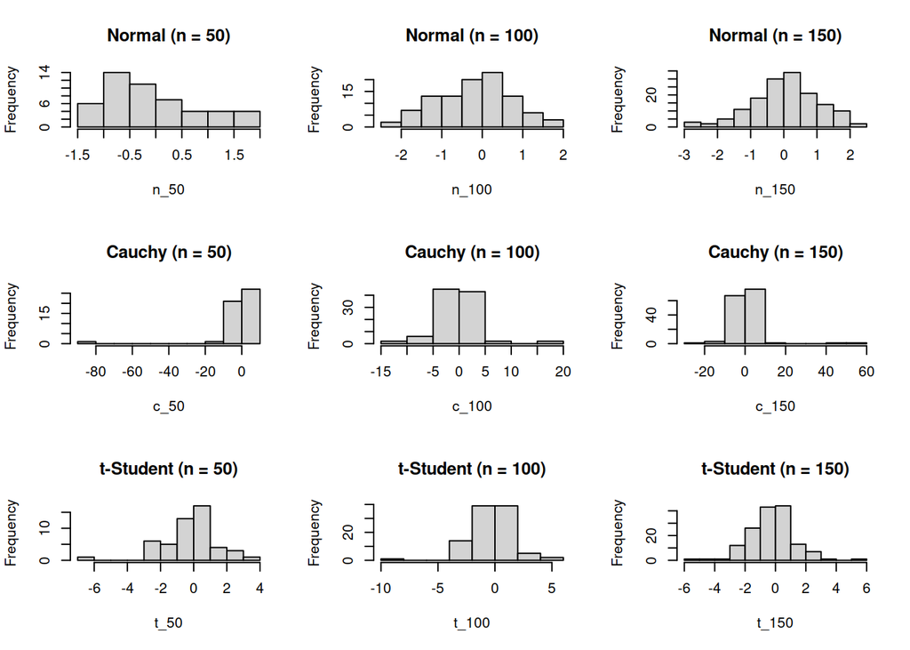

```r
n_50 <- rnorm(50, mean = 0, sd = 1)
c_50 <- rcauchy(50, location = 0, scale = 1)
t_50 <- rt(50, df = 4)

n_100 <- rnorm(100, mean = 0, sd = 1)
c_100 <- rcauchy(100, location = 0, scale = 1)
t_100 <- rt(100, df = 4)

n_150 <- rnorm(150, mean = 0, sd = 1)
c_150 <- rcauchy(150, location = 0, scale = 1)
t_150 <- rt(150, df = 4)



# Conf o layout para 3 gráficos lado a lado
par(mfrow = c(3, 3))

# Distribuição Normal
hist(n_50, main = "Normal (n = 50)")


hist(n_100, main = "Normal (n = 100)")


hist(n_150, main = "Normal (n = 150)")


# Distribuição Cauchy
hist(c_50,  main = "Cauchy (n = 50)")

hist(c_100, main = "Cauchy (n = 100)")

hist(c_150, main = "Cauchy (n = 150)")

# Distribuição t-Student
hist(t_50,main = "t-Student (n = 50)")

hist(t_100, main = "t-Student (n = 100)")

hist(t_150,main = "t-Student (n = 150)")
```

```r
par(mfrow = c(1, 1))
```

##### (c) Calcule as estimativas de ∆( b F, G) para cada amostra das distribuições de referência F obtidas no item (b) e a amostra da distribuição desconhecida G, obtida no arquivo de dados anexo.

```r
amostra_G <- scan("dados.csv", what = numeric(), sep = "\n")
```

- Distribuição Normal Padrão e Amostra desconhecida G;

```r
delta_est(n_50,amostra_G)
```

```
## [1] 0.003893135
```

```r
delta_est(n_100,amostra_G)
```

```
## [1] 0.003048485
```

```r
delta_est(n_150,amostra_G)
```

```
## [1] 0.002595485
```

- Distribuição T-Student (4) e Amostra desconhecida G

```r
delta_est(t_50,amostra_G)
```

```
## [1] -0.002196908
```

```r
delta_est(t_100,amostra_G)
```

```
## [1] -0.002238384
```

```r
delta_est(t_150,amostra_G)
```

```
## [1] -0.0002154792
```

- Distribuição Cauchy Padrão e Amostra desconhecida G

```r
delta_est(c_50,amostra_G)
```

```
## [1] -0.001816863
```

```r
delta_est(c_100,amostra_G)
```

```
## [1] -0.001874747
```

```r
delta_est(c_150,amostra_G)
```

```
## [1] -0.001401939
```

### 3. Estimador não Viciado de mínima variância

##### Sejam X1,X2,···,Xm e Y1,Y2,···,Yn amostras independentes de duas distribuições absolutamente contínuas. Encontre o estimador não viciado de mínima variância de:

```r
X <- rnorm(10000,5,3)

Y <- rexp(15000,4)
```

- 1. E(XY)

```r
mean(X)*mean(Y) #Se independentes, a E(XY) = E(X)*E(Y)
```

```
## [1] 1.245899
```

- 2. Var(X + Y).

```r
var(X) + var(Y) #Se independentes, VAR(X + Y) = VAR(X) + VAR(Y)
```

```
## [1] 9.036513
```

### 4. Função densidade Estimada

Podemos considerar a densidade kernel estimada como a função de densidade de uma amostra, como obter então novas amostras?

Como o estimador kernel da função de densidade

$$f_{bn}(x) = \frac{1}{n h_n} \sum_{i=1}^{n} K \left( \frac{x - X_i}{h_n}
\right)$$

é uma mistura de $n$ componentes de kernel, cada um pode ser amostrado independentemente.

A única parte que pode exigir tratamento especial é a amostragem da densidade $K$, embora para a maioria dos kernels implementados R possam ser encontradas funções de amostragem específicas.

Consideremos os dados em:

```r
phipsi <- read.csv("http://leg.ufpr.br/~lucambio/Nonparam/phipsi.csv",
                   sep = ",", header = TRUE)


psi <- phipsi$psi
```

Execute o seguinte algoritmo para gerar amostras de tamanho N, a partir da densidade kernel estimada dos dados em phipsi:

- 1. Escolha i ∈ {1,···,n} aleatoriamente.;

```r
n <- length(psi)

hn <- density(psi)$bw

i <- sample(1:n,size = 1)
```

- 2. Obtenha um amostra de tamanho 1 da densidade K, caso utilizese a densidade gaussiana, a média é Xi e o desvio padrão é hn;

```r
  i <- sample(1:n, 1)
  amostra_kernel <- rnorm(1, mean = psi[i], sd = hn)
```

- 3. Repita os passos anteriores N vezes;

```r
amostra_kernel <- numeric(600)

for (j in 1:600) {
  i <- sample(1:n, 1)  # Passo (i)
  amostra_kernel[j] <- rnorm(1, mean = psi[i], sd = hn)  # Passo (ii)
}
```

Obtenha uma amostra de tamanho N = 600 da variável ψ (phipsi$psi) utilizando o algoritmo acima e compare a densidade estimada da nova amostra com a densidade estimada de ψ. Esta compara¸c˜ao pode ser graficamente.

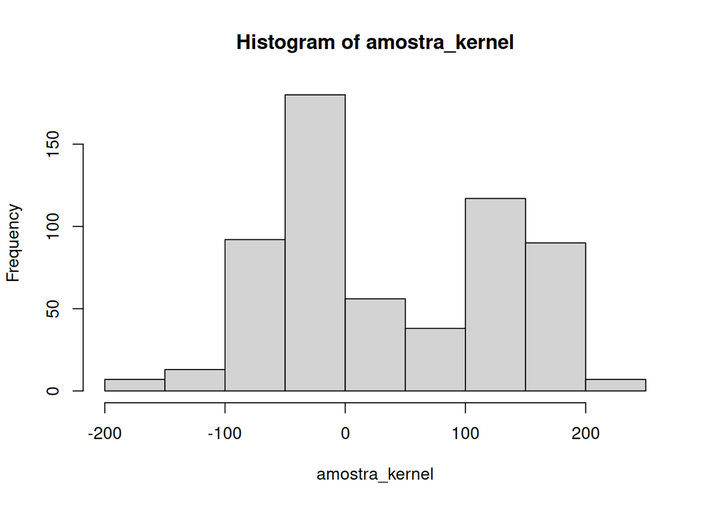

```r
hist(amostra_kernel)
```

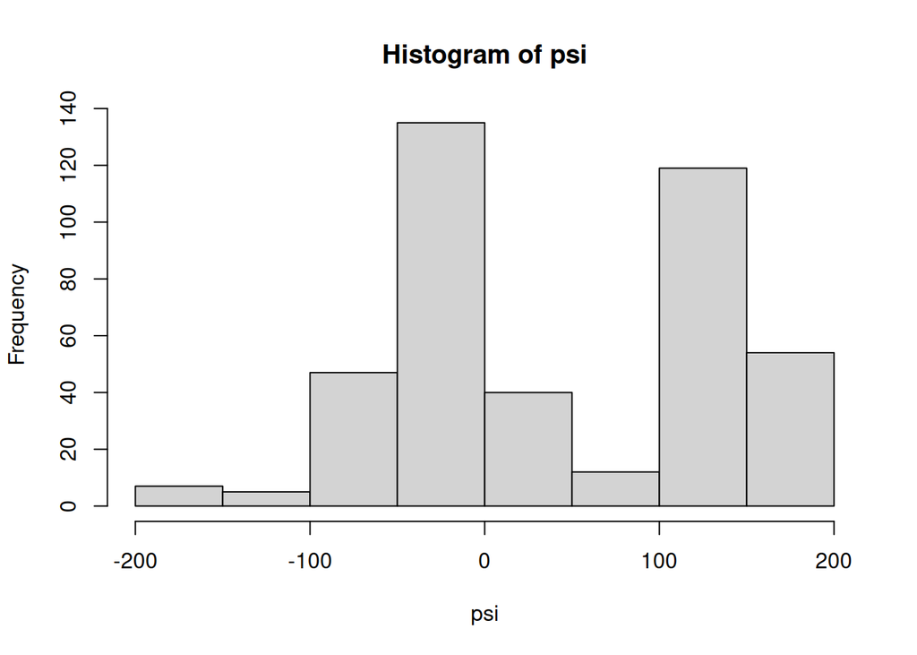

```r
hist(psi)
```